# FSSA Algorithm: Part 2 Decomposition Stage

The next step in the FSSA algorithm for our univariate example is decomposition of the call center fts object into principal components. These principal components are the main building blocks of what make up the data. They are orthonormal to one another and will be used for reconstruction to approximate the original fts object. One could think of this step as denoising the data and trying to find the most informative pieces of the data that expose trend, seasonality, and other components that will be interesting. We achieve this by performing a singular value decomposition (SVD) of the trajectory operator that results from the embedding step of FSSA which is also performed as a part of the ‘fssa’ function.

For our univariate call center example, we choose a lag of 28 to try to expose the daily pattern of call center data within a week (4 weeks in a month with 7 days in a week).

```r
L=28
U=fssa(Y,L)
```

We obtain the functional singular spectrum analysis (fssa) object U which contains the principal components (eigenfunctions) and all the additional information that comes with those components such as associated eigenvalues. With our components, we want to reconstruct into additive fts objects whose sum approximates the original fts object but without the noise components involved. We also want to do the reconstructions such that we separate out the trend term from the periodic term and so forth. This grouping of fssa objects can be done heuristically by looking at plots of the decomposition. For our call center example, we start with the scree plot of singular values.

These singular values capture how much energy or information is stored within each prinicipal component. We see that the first component contains most of the variation in the data and subsequent components contain less variation in the data. Notice that the second and third singular values are similar in magnitude, this is a clue that we may want to group the second and third components together for reconstruction.

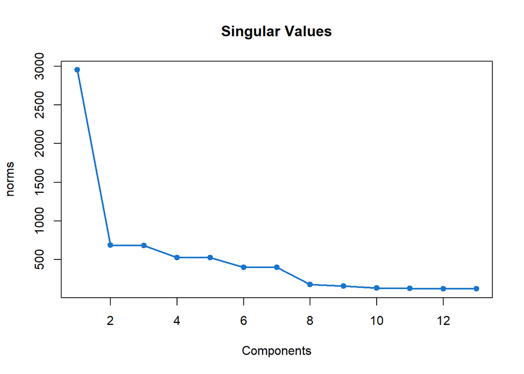

```r
plot(U,d=13)
```

This plot is a heat map of the principal components and shows periodic patterns that are present in each of the components. Again, we see similar periodic behavior between the second and third components strengthening our argument to group these two together for reconstruction. We see four and five also have a similar pattern compared to each other and the same goes for six and seven.

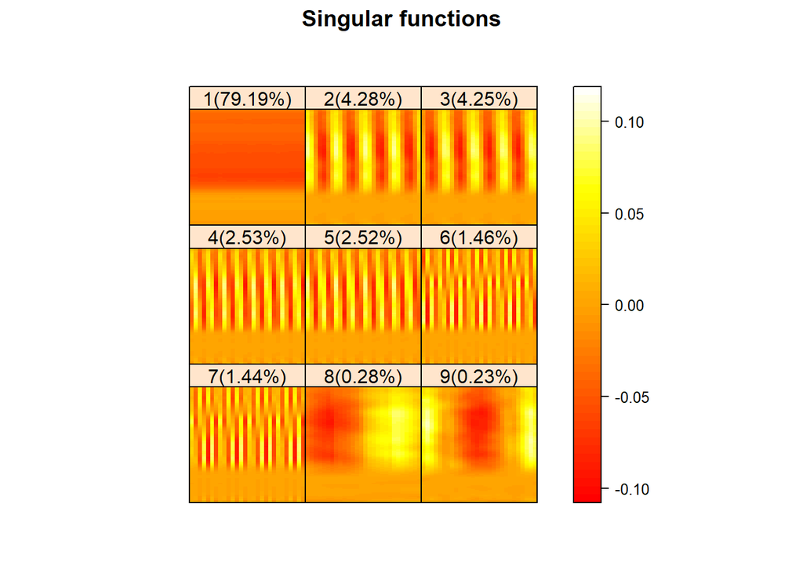

```r
plot(U,d=9,type="lheats")
```

This plot is of the principal components which gives us information into what types of behaviors they best capture. We see that the first component seems to capture some overarching trend while the second, third, fourth, fifth, sixth, and seventh seem to all capture some sort of daily periodic behavior as expected. Each of these components have seven distinct curves of information which tells us that they are capturing information about calls to the center on each of the seven days of the week.

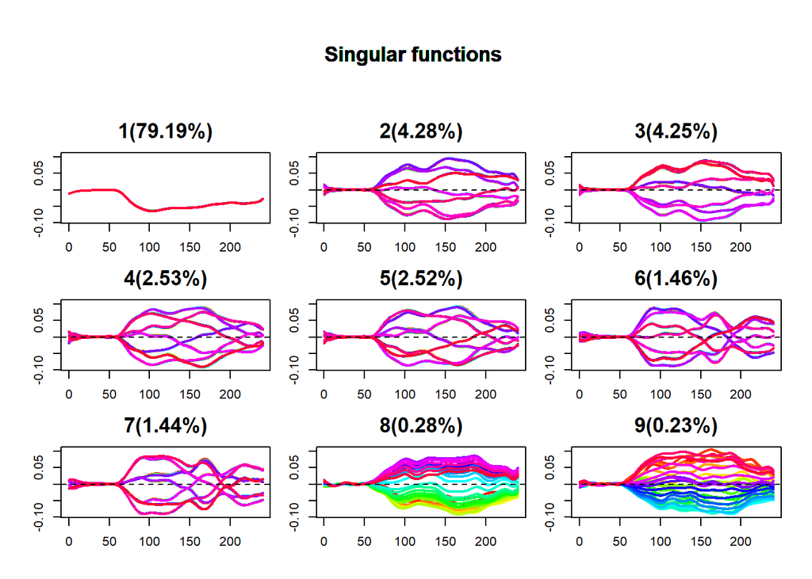

```r
plot(U,d=9,type="lcurves")
```

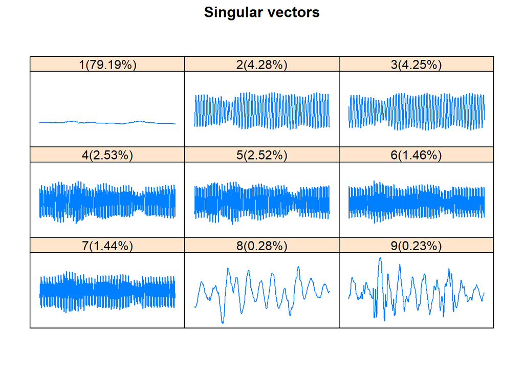

```r
plot(U,d=9,type="vectors")
```

This periodogram plot is another way to find the within day periodicity across functions which gives us clues into sampling frequency.

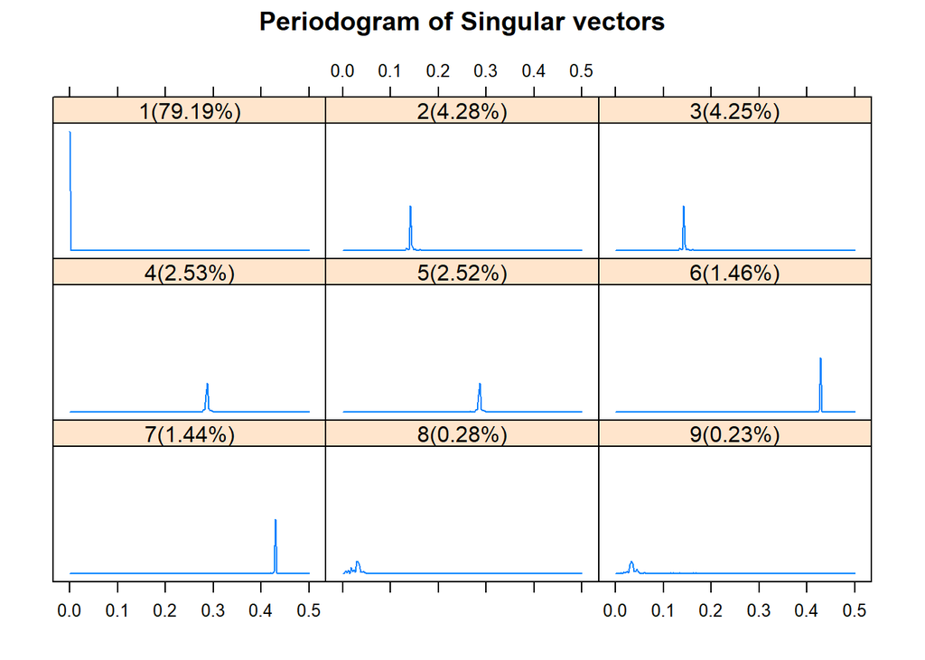

```r
plot(U,d=9,type="periodogram")
```

The paired plot is probably one of the most important plots when coming up with a suitable grouping for reconstruction. It exposes how principal components behave with one another especially in a periodic sense. If principal components form a nice geometry with one another when plotted together, then a nice grouping is exposed and in addition, the geometry tells us what type of periodicity those principal components capture. For this call center example, we see that the second and third component have a nice geometry, four and five also have a nice geometry, and so do six and seven. Each one of these geometric shapes have seven points which indicates they are capturing daily behavior of calls received by the center during each of the distinct seven days of the week.

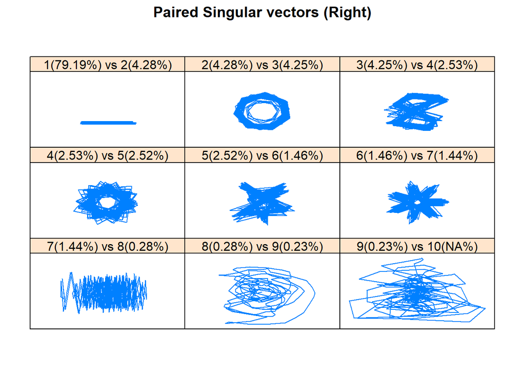

```r
plot(U,d=9,type="paired")
```

In addition to these plots of principal components, can analyze the weighted correlation (w-correlation) matrix plot which showcases the correlation of fts objects that are formed from reconstructions using each principal component individually in the grouping. So, if we set the ‘d’ parameter to be nine, we form nine different fts objects that were each reconstructed individually using only one of the first nine principal components. Those fts objects with a higher correlation (darker squares) should be grouped together. This plot is also nice because it also makes it easy to distinguish useful components from components that only capture noise. For the call center data example, we again see that one should be grouped by itself, two with three, four with five, and six with seven.

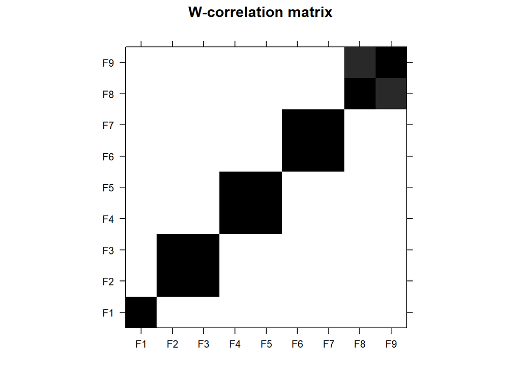

```r
plot(U,d=9,type="wcor")
```

We can also perform the decomposition stage of multivariate functional singular spectrum analysis (mfssa), which follows a similar flavor to that of the univariate case, using our NDVI and EVI bivariate example using the following.

We choose 45 (which corresponds to taking images over the course of just under two years) for our lag here to try to not only capture the seasonality behavior in the fts object that is present due to changing seasons which we discussed before, but to see if we can capture other longer types of periodic behavior such as possibly five year long oscillations in vegetation density.

```r
L=45
## Multivariate functional singular spectrum analysis
U=fssa(Y,L)
```

Like in the univariate case, we can find a suitable grouping for reconstruction using plots.

As expected, the first singular values shows that the first principal component captures trend and most of the information in our densities of NDVI and EVI images, the second and third are likely going to capture the seasonal changes in vegetation densities, but there’s also an interesting fourth component that we capture here that has some variablity associated with it.

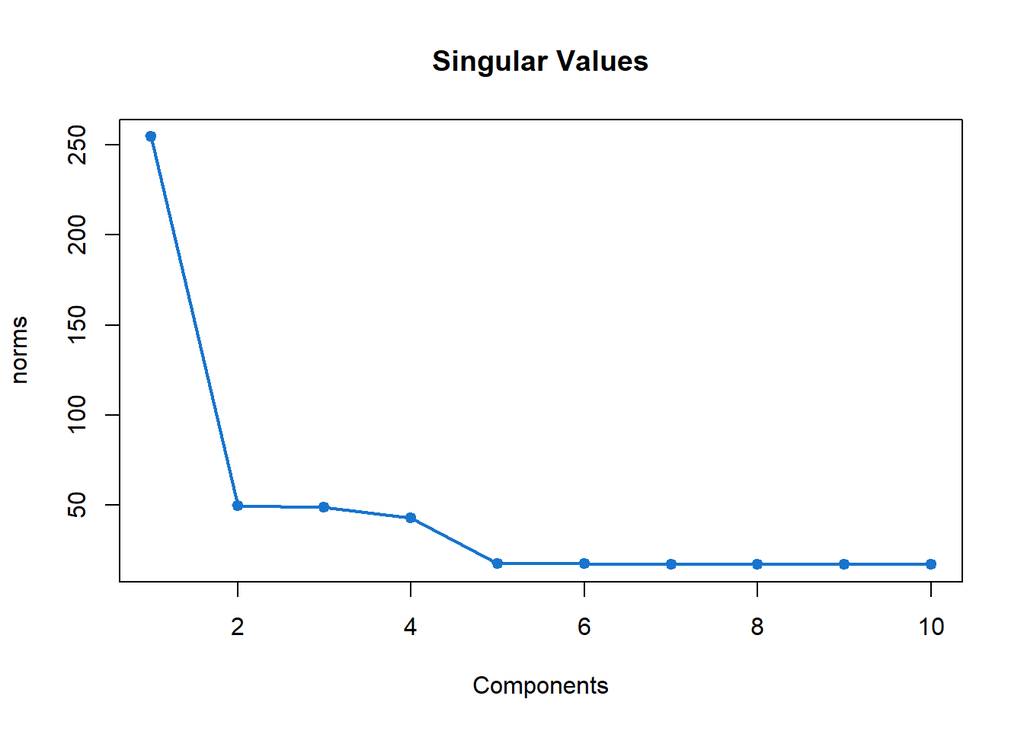

```r
plot(U, d=10, type='values')
```

The paired-plots offer information that the second and third component should be grouped together and it appears that it is capturing the season changes in vegetation but we don’t get as much information out of this plot as we did in the univariate case.

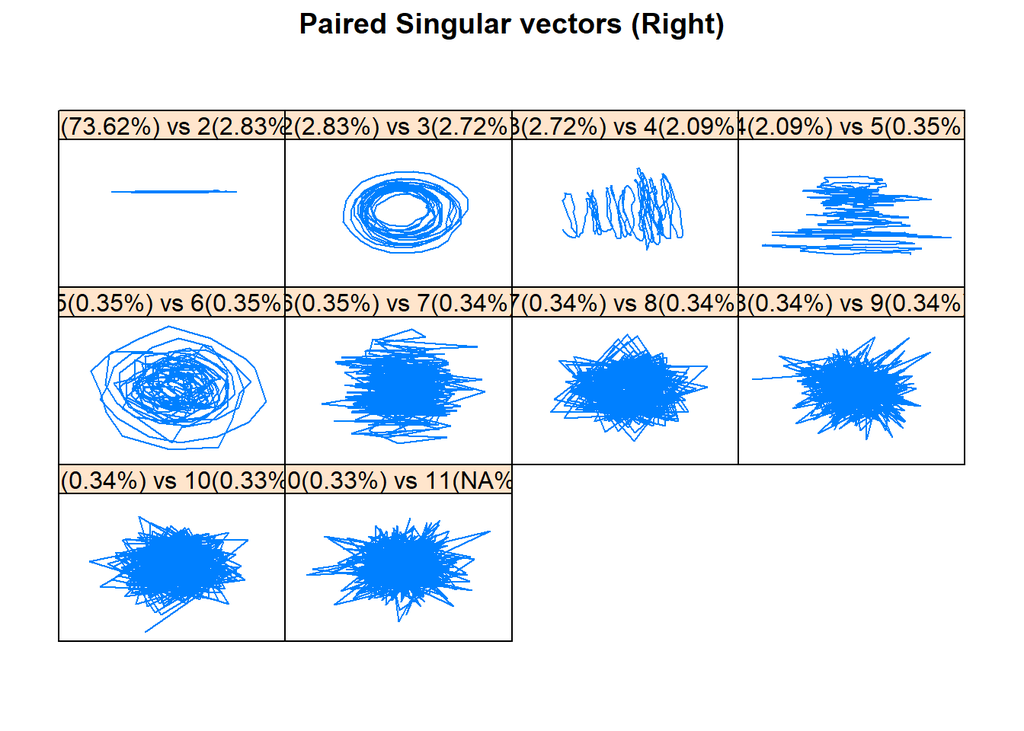

```r
plot(U,d=10,type='paired')
```

Here, we see that the second and third components are giving us the four seasons information we are looking for in the NDVI data.

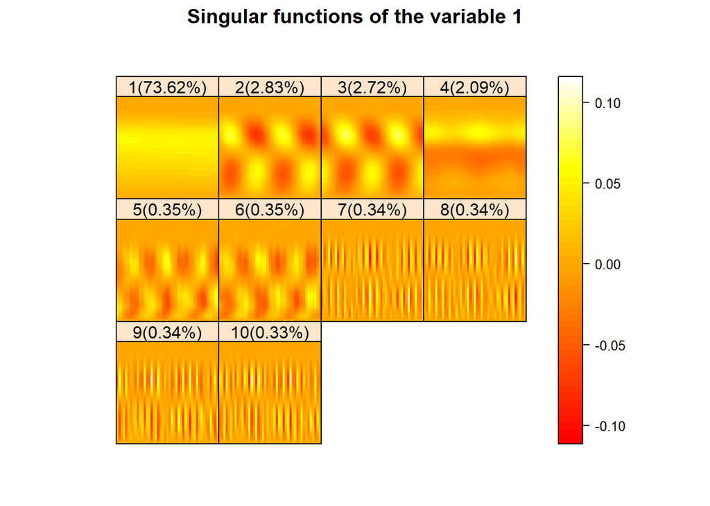

```r
plot(U,d=10,type='lheats', var = 1)
```

Here, we see that the singular functions are showing that the first component captures trend in the NDVI densities, the second and third components capture oscillatory season patterns in the pixel densities, adn the fourth component captures some interesting switch in the overarching pixel densities.

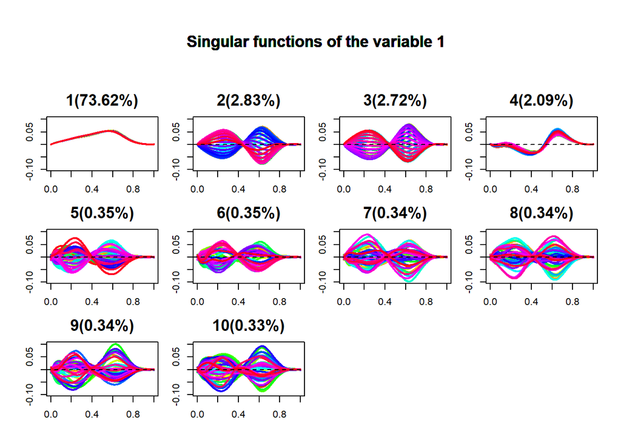

```r
plot(U,d=10,type='lcurves',var = 1)
```

The heat plots and singular function plots for the EVI data tell us a lot of the same information that was presented with the NDVI pixel densities.

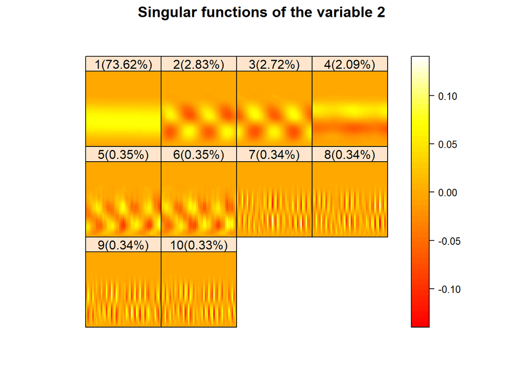

```r
plot(U,d=10,type='lheats', var = 2)
```

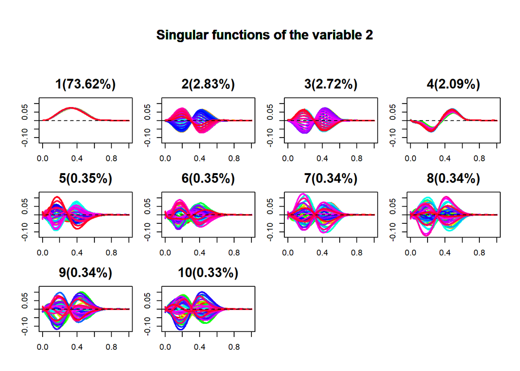

```r
plot(U,d=10,type='lcurves',var = 2)
```

The right singular vectors tell us seasonality due to changes in season is present in the NDVI and EVI data as seen in the second and third vectors while the fourth vector captures some interesting decrease in pixel density value.

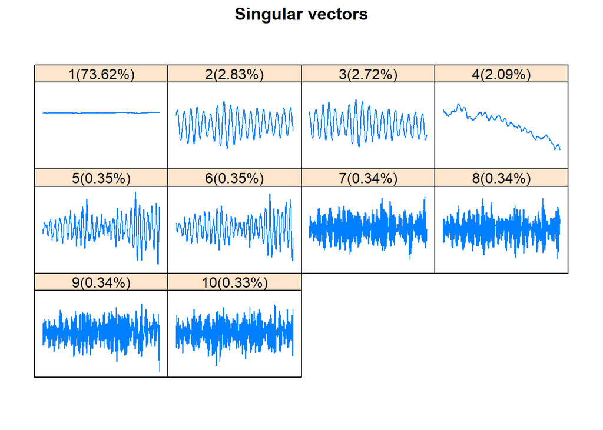

```r
plot(U,d=10,type='vectors')
```

The periodogram also gives us hints into seasonality in the second and third components.

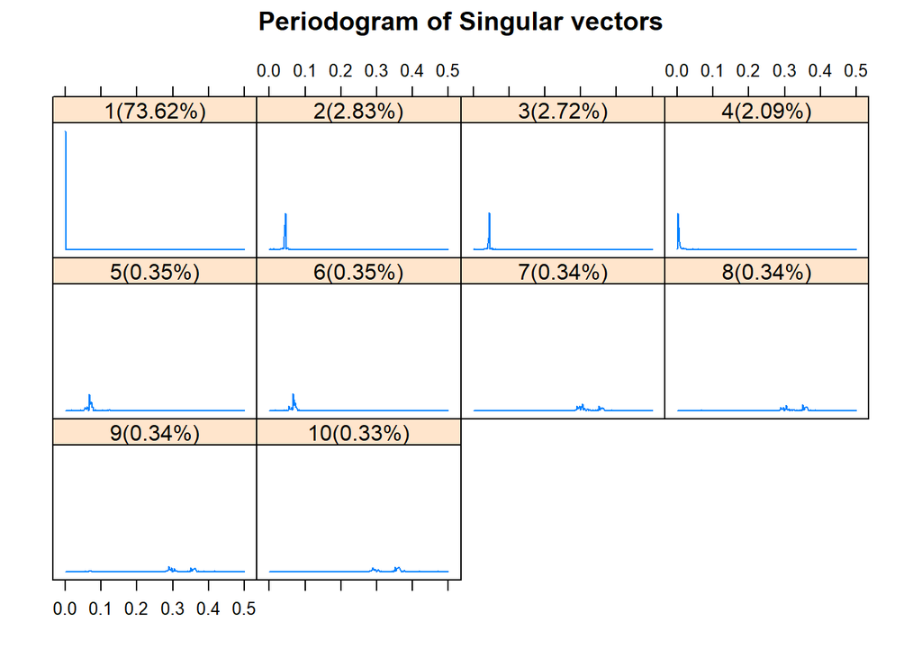

```r
plot(U,d=10,type='periodogram')
```

The w-correlation matrix and plots that we have seen so far show that the first component should be grouped as itself for trend, the second and third for seasons oscillations, and the fourth by itself. All other components appear to capture more noise components and will not be included in reconstructions.

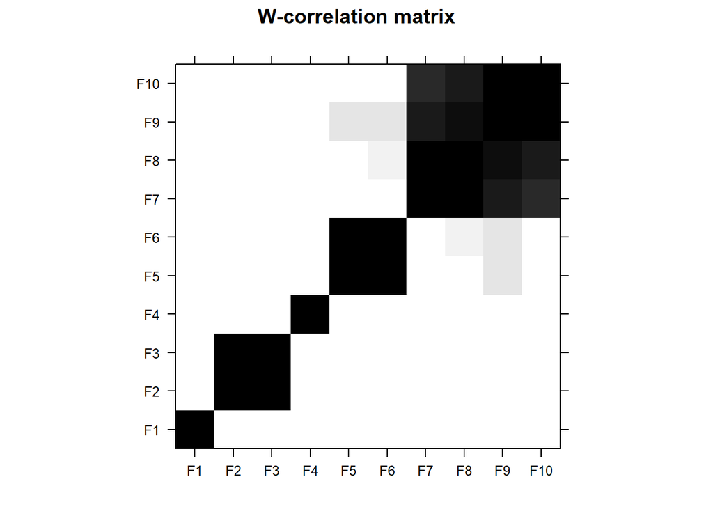

```r
plot(U,d=10,type='wcor')
```

At this point, we have found suitable groups and some interesting information from our univariate and multivariate examples with FSSA. Now that we have our groupings and we know more information about the data, we can reconstruct our principal components into additive components.